# ---------------Madagascar Project------------------

## Mercator distance(2 controls point)

#### This code calculates the Euclidean distances between three points in the Mercator projection coordinate system. First, the coordinates of points 8, 12, and 5 are extracted. The distance between points 8 and 12 is calculated using the Euclidean distance formula, and the result is converted from meters to kilometers by dividing by 1000. Similarly, the distance between points 8 and 5 is computed and converted to kilometers. Finally, the total distance in the Mercator projection is obtained by summing these two segment distances.

```python
point_8_mercator_latitude = flight_coordinates['mercator_y_2c'].iloc[1]
point_8_mercator_longitude = flight_coordinates['mercator_x_2c'].iloc[1]
point_12_mercator_latitude = flight_coordinates['mercator_y_2c'].iloc[2]
point_12_mercator_longitude = flight_coordinates['mercator_x_2c'].iloc[2]
distance_12_8_mercator_2c = np.sqrt((point_12_mercator_longitude - point_8_mercator_longitude)**2 +
                                    (point_12_mercator_latitude - point_8_mercator_latitude)**2)
distance_12_8_mercator_km_2c = distance_12_8_mercator_2c / 1000
point_5_mercator_latitude = flight_coordinates['mercator_y_2c'].iloc[0]
point_5_mercator_longitude = flight_coordinates['mercator_x_2c'].iloc[0]
distance_8_5_mercator_2c = np.sqrt((point_8_mercator_longitude - point_5_mercator_longitude)**2 +
                                    (point_8_mercator_latitude - point_5_mercator_latitude)**2)
distance_8_5_mercator_km_2c = distance_8_5_mercator_2c / 1000
total_mercator_projection_distance_2c= distance_12_8_mercator_km_2c + distance_8_5_mercator_km_2c
print(str(total_mercator_projection_distance_2c) + ' km')
```

```
1547.8721224618705 km
```

```
1547.8721224618705 km
```

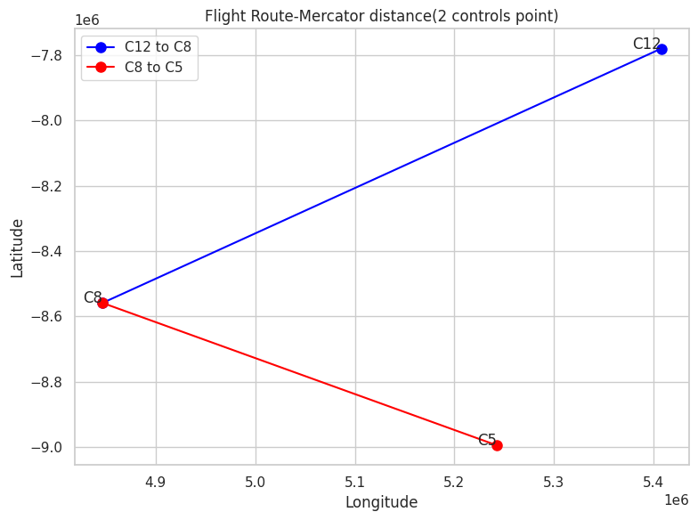

```python
# Extract coordinates for the points
point_8_mercator_latitude = flight_coordinates['mercator_y_2c'].iloc[1]
point_8_mercator_longitude = flight_coordinates['mercator_x_2c'].iloc[1]
point_12_mercator_latitude = flight_coordinates['mercator_y_2c'].iloc[2]
point_12_mercator_longitude = flight_coordinates['mercator_x_2c'].iloc[2]
point_5_mercator_latitude = flight_coordinates['mercator_y_2c'].iloc[0]
point_5_mercator_longitude = flight_coordinates['mercator_x_2c'].iloc[0]

# Calculate distance between C12 and C8
distance_12_8_mercator = np.sqrt((point_12_mercator_longitude - point_8_mercator_longitude)**2 +
                                 (point_12_mercator_latitude - point_8_mercator_latitude)**2)
distance_12_8_mercator_km = distance_12_8_mercator / 1000  # Convert to kilometers

# Calculate distance between C8 and C5
distance_8_5_mercator = np.sqrt((point_8_mercator_longitude - point_5_mercator_longitude)**2 +
                                (point_8_mercator_latitude - point_5_mercator_latitude)**2)
distance_8_5_mercator_km = distance_8_5_mercator / 1000  # Convert to kilometers

# Calculate total distance
total_mercator_projection_distance = distance_12_8_mercator_km + distance_8_5_mercator_km
print(str(total_mercator_projection_distance) + ' km')

# Plot the flight route
plt.figure(figsize=(8, 6))

# Plot the route from C12 to C8
plt.plot([point_12_mercator_longitude, point_8_mercator_longitude],
         [point_12_mercator_latitude, point_8_mercator_latitude],
         color='blue', marker='o', markersize=8, label="C12 to C8")

# Plot the route from C8 to C5
plt.plot([point_8_mercator_longitude, point_5_mercator_longitude],
         [point_8_mercator_latitude, point_5_mercator_latitude],
         color='red', marker='o', markersize=8, label="C8 to C5")

# Annotate the points
plt.text(point_12_mercator_longitude, point_12_mercator_latitude, 'C12', fontsize=12, ha='right')
plt.text(point_8_mercator_longitude, point_8_mercator_latitude, 'C8', fontsize=12, ha='right')
plt.text(point_5_mercator_longitude, point_5_mercator_latitude, 'C5', fontsize=12, ha='right')

# Set the title and labels
plt.title("Flight Route-Mercator distance(2 controls point)")
plt.xlabel("Longitude")
plt.ylabel("Latitude")

# Show the legend
plt.legend()

# Display the plot
plt.tight_layout()
plt.show()
```

## Mercator distance(4 controls point)

#### This code calculates the Euclidean distances between three points in the Mercator projection coordinate system. First, the coordinates of points 8, 12, and 5 are extracted. The distance between points 8 and 12 is calculated using the Euclidean distance formula, and the result is converted from meters to kilometers by dividing by 1000. Similarly, the distance between points 8 and 5 is computed and converted to kilometers. Finally, the total distance in the Mercator projection is obtained by summing these two segment distances.

```python
point_8_mercator_latitude = flight_coordinates['North_Transformed'].iloc[1]
point_8_mercator_longitude = flight_coordinates['East_Transformed'].iloc[1]
```

```python
point_12_mercator_latitude = flight_coordinates['North_Transformed'].iloc[2]
point_12_mercator_longitude = flight_coordinates['East_Transformed'].iloc[2]
```

```python
distance_12_8_mercator = np.sqrt((point_12_mercator_longitude - point_8_mercator_longitude)**2 +
                                    (point_12_mercator_latitude - point_8_mercator_latitude)**2)
```

```python
distance_12_8_mercator_km = distance_12_8_mercator / 1000
```

```python
point_5_mercator_latitude = flight_coordinates['North_Transformed'].iloc[0]
point_5_mercator_longitude = flight_coordinates['East_Transformed'].iloc[0]
```

```python
distance_8_5_mercator = np.sqrt((point_8_mercator_longitude - point_5_mercator_longitude)**2 +
                                    (point_8_mercator_latitude - point_5_mercator_latitude)**2)
```

```python
distance_8_5_mercator_km = distance_8_5_mercator / 1000
```

```python
total_mercator_projection_distance=distance_12_8_mercator_km + distance_8_5_mercator_km
print(str(total_mercator_projection_distance) + ' km')
```

```
1546.2770660005715 km
```

```
Total distance: 1546.2770660005715 km
```

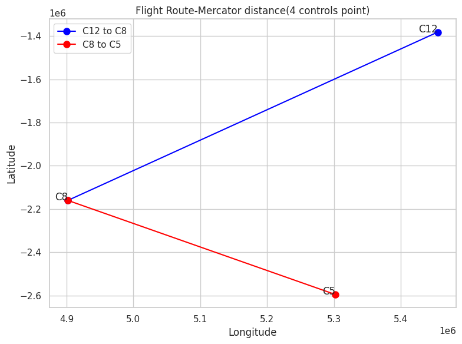

```python
# Extract coordinates for the points from the transformed flight coordinates
point_8_mercator_latitude = flight_coordinates['North_Transformed'].iloc[1]
point_8_mercator_longitude = flight_coordinates['East_Transformed'].iloc[1]
point_12_mercator_latitude = flight_coordinates['North_Transformed'].iloc[2]
point_12_mercator_longitude = flight_coordinates['East_Transformed'].iloc[2]
point_5_mercator_latitude = flight_coordinates['North_Transformed'].iloc[0]
point_5_mercator_longitude = flight_coordinates['East_Transformed'].iloc[0]

# Calculate distance between C12 and C8
distance_12_8_mercator = np.sqrt((point_12_mercator_longitude - point_8_mercator_longitude)**2 +
                                 (point_12_mercator_latitude - point_8_mercator_latitude)**2)
distance_12_8_mercator_km = distance_12_8_mercator / 1000  # Convert to kilometers

# Calculate distance between C8 and C5
distance_8_5_mercator = np.sqrt((point_8_mercator_longitude - point_5_mercator_longitude)**2 +
                                (point_8_mercator_latitude - point_5_mercator_latitude)**2)
distance_8_5_mercator_km = distance_8_5_mercator / 1000  # Convert to kilometers

# Calculate total distance
total_mercator_projection_distance = distance_12_8_mercator_km + distance_8_5_mercator_km
print(f'Total distance: {total_mercator_projection_distance} km')

# Plot the flight route
plt.figure(figsize=(8, 6))

# Plot the route from C12 to C8
plt.plot([point_12_mercator_longitude, point_8_mercator_longitude],
         [point_12_mercator_latitude, point_8_mercator_latitude],
         color='blue', marker='o', markersize=8, label="C12 to C8")

# Plot the route from C8 to C5
plt.plot([point_8_mercator_longitude, point_5_mercator_longitude],
         [point_8_mercator_latitude, point_5_mercator_latitude],
         color='red', marker='o', markersize=8, label="C8 to C5")

# Annotate the points on the plot
plt.text(point_12_mercator_longitude, point_12_mercator_latitude, 'C12', fontsize=12, ha='right')
plt.text(point_8_mercator_longitude, point_8_mercator_latitude, 'C8', fontsize=12, ha='right')
plt.text(point_5_mercator_longitude, point_5_mercator_latitude, 'C5', fontsize=12, ha='right')

# Set the title and labels for the plot
plt.title("Flight Route-Mercator distance(4 controls point)")
plt.xlabel("Longitude")
plt.ylabel("Latitude")

# Display the legend
plt.legend()

# Show the plot
plt.tight_layout()
plt.show()
```